# Homework5_AdrianKlausen

Homework assignment. Week 5. Adrian Klausen.

```python
import pandas as pd
df = pd.read_csv("HomeworkDATA.csv") #This dataset contains the 13 largest Estonian theatres by number of visitors. (From my week 4 homework submission.)
df
```

|  | Theatre | in-house performances | off-site performances | TOTAL PERFORMANCES | in-house visitors | off-site visitors | TOTAL VISITORS | ONLINE |
| --- | --- | --- | --- | --- | --- | --- | --- | --- |
| 0 | Vanemuine | 353 | 78 | 431 | 121538 | 22735 | 144273 | 0 |
| 1 | Eesti Draamateater | 384 | 67 | 451 | 107497 | 20512 | 128009 | 0 |
| 2 | Ugala Teater | 255 | 98 | 353 | 58135 | 25840 | 83975 | 0 |
| 3 | Endla Teater | 148 | 216 | 364 | 35300 | 45662 | 80962 | 0 |
| 4 | Eesti Noorsooteater | 364 | 110 | 474 | 56980 | 11365 | 68345 | 0 |
| 5 | Rakvere Teater | 197 | 152 | 349 | 29799 | 30202 | 60001 | 0 |
| 6 | Südalinna Teater | 296 | 32 | 328 | 47375 | 5358 | 52733 | 0 |
| 7 | VAT Teater | 24 | 141 | 165 | 2782 | 22271 | 25053 | 201 |
| 8 | Teater Nuutrum | 64 | 83 | 147 | 8865 | 15989 | 24854 | 0 |
| 9 | Kellerteater | 33 | 123 | 156 | 2929 | 18490 | 21419 | 0 |
| 10 | Piip ja Tuut Teater | 98 | 98 | 196 | 5646 | 15711 | 21357 | 0 |
| 11 | Teater Sõber | 0 | 220 | 220 | 0 | 19295 | 19295 | 0 |
| 12 | Von Krahli Teater | 142 | 16 | 158 | 16635 | 1302 | 17937 | 0 |

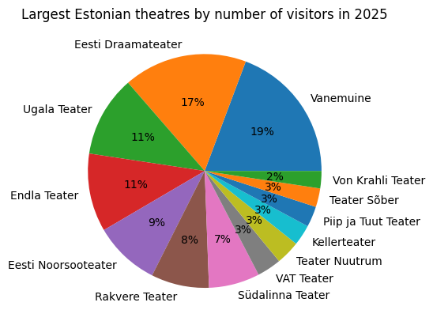

```python
import matplotlib.pyplot as plt
df.plot(kind="pie", y="TOTAL VISITORS", labels=df["Theatre"], legend=False, autopct="%1.f%%")
plt.title("Largest Estonian theatres by number of visitors in 2025")
plt.ylabel("")
plt.show()
```

This chart lets us examine the visitation numbers in proportion to eachother. As we can see, Vanemuine was the largest theatre of 2025 by the number of visitors, with Eesti Draamateater close behind.

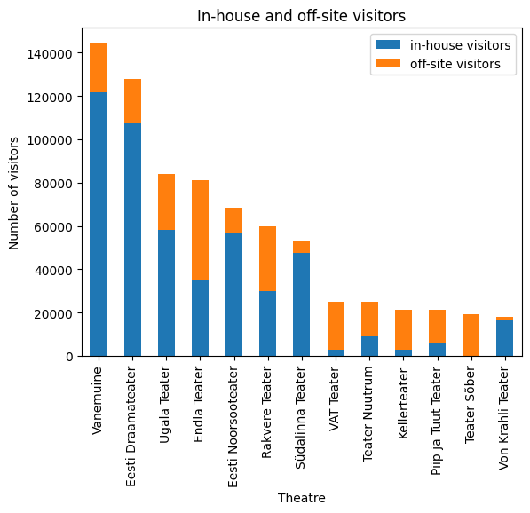

```python
df.plot(kind="bar", x="Theatre", y=["in-house visitors", "off-site visitors"], stacked=True)
plt.title("In-house and off-site visitors")
plt.ylabel("Number of visitors")
plt.xlabel("Theatre")
plt.legend
plt.show()
```

This chart shows the number of in-house and off-site visitors for each theatre. A stacked bar chart is useful, because with it, we can see both the total number of vistors, and what that total is comprised of. Endla Teater is the largest one on the chart to have 50% or more of its viewers be off-site. Notably, Teater Sõber only has off-site visitors (and off-site perfomances).

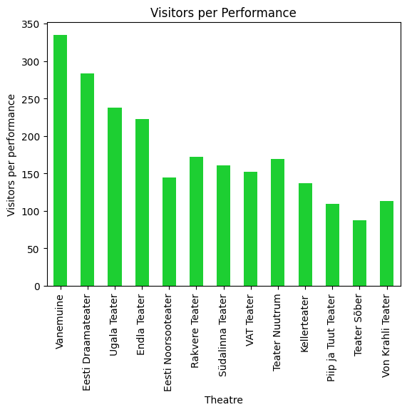

```python
df["VISITORS PER PERFORMANCE"] = (df["TOTAL VISITORS"] / df["TOTAL PERFORMANCES"])
df.plot(kind="bar", x="Theatre", y="VISITORS PER PERFORMANCE", legend=False, color="#1dcf32")
plt.title("Visitors per Performance")
plt.ylabel("Visitors per performance")
plt.xlabel("Theatre")
plt.show()
```